# aer13_FinalHomeworkCode_03

Abby_Robinson

10/14/2021

#Some of My Best Friends are Zombies…

Load necessary packages using library() function

```r
library(curl)
```

```r
library(ggplot2)
library(tidyverse)
```

load dataset using curl() function

```r
f <- curl("https://raw.githubusercontent.com/fuzzyatelin/fuzzyatelin.github.io/master/AN588_Fall21/zombies.csv")
zombies <- read.csv(f, header = TRUE, sep = ",", stringsAsFactors = FALSE)
zombies
```

[output not shown]

[output cut: 1987 more lines]

##1. Calculate the population mean and standard deviation for each quantitative random variable (height, weight, age, number of zombies killed, and years of education). NOTE: You will not want to use the built in var() and sd() commands as these are for samples.

```r
s <- select(zombies, "height", "weight", "age", "zombies_killed", "years_of_education")
#select() function can be used to select only the quantitative varaibles from the dataset

x <- s
#name "x" as the selected data to run the pop_sd function below

pop_v <- function(x) {
    sum((x - mean(x))^2)/(length(x))
}

pop_sd <- function(x) {
    sqrt(pop_v(x))
}
pop_sd(x)
```

```
## [1] NA
```

```r
#write function to calculate population standard deviation

?cbind
cbind(mean = apply(s, 2, mean), pop_sd = apply(s, 2, pop_sd))
```

```
##                         mean    pop_sd
## height              67.63010  4.307970
## weight             143.90748 18.391857
## age                 20.04696  2.963583
## zombies_killed       2.99200  1.747551
## years_of_education   2.99600  1.675704
```

```r
#cbind function allows you to group the mean and standard deviation values for all variables in the output
```

##2. Use {ggplot} to make boxplots of each of these variables by gender.

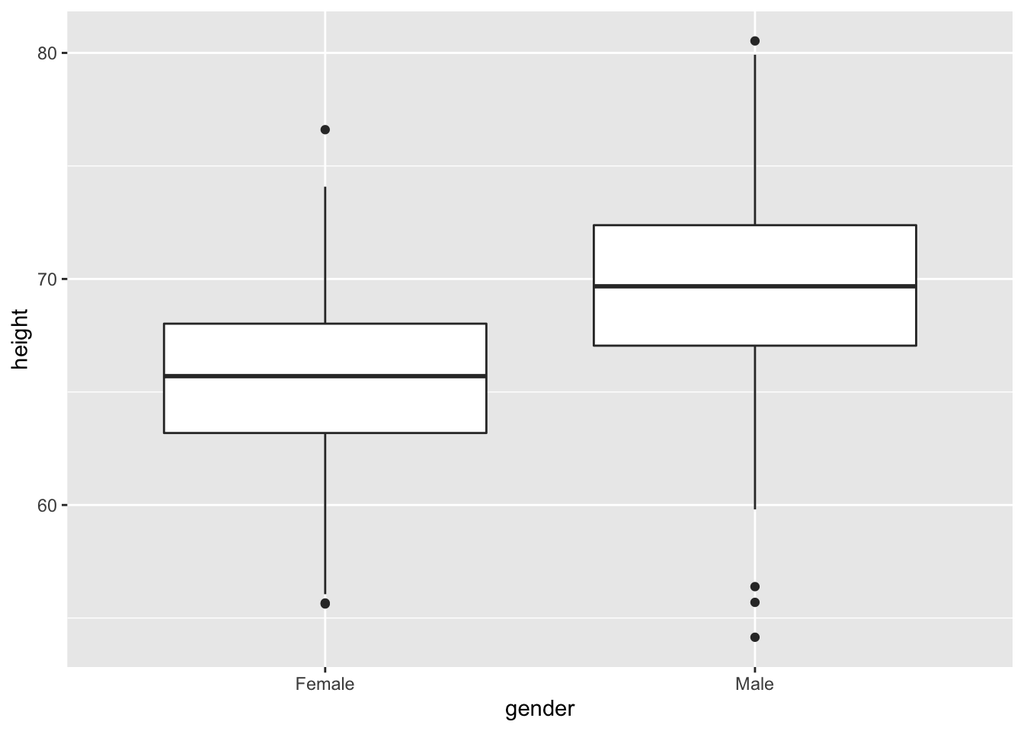

```r
library(ggplot2)
library(gridExtra) #Package that allows drawing multiple ggplot plots
height <- ggplot(data = zombies, aes(x = gender, y = height))
height <- height + geom_boxplot()
height
```

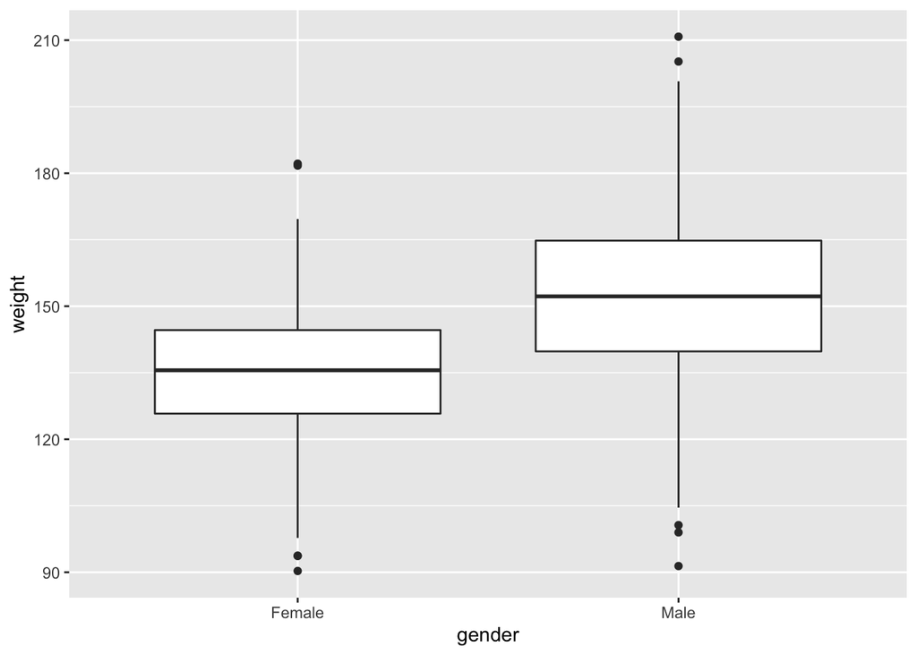

```r
weight <- ggplot(data = zombies, aes(x = gender, y = weight))
weight <- weight + geom_boxplot()
weight
```

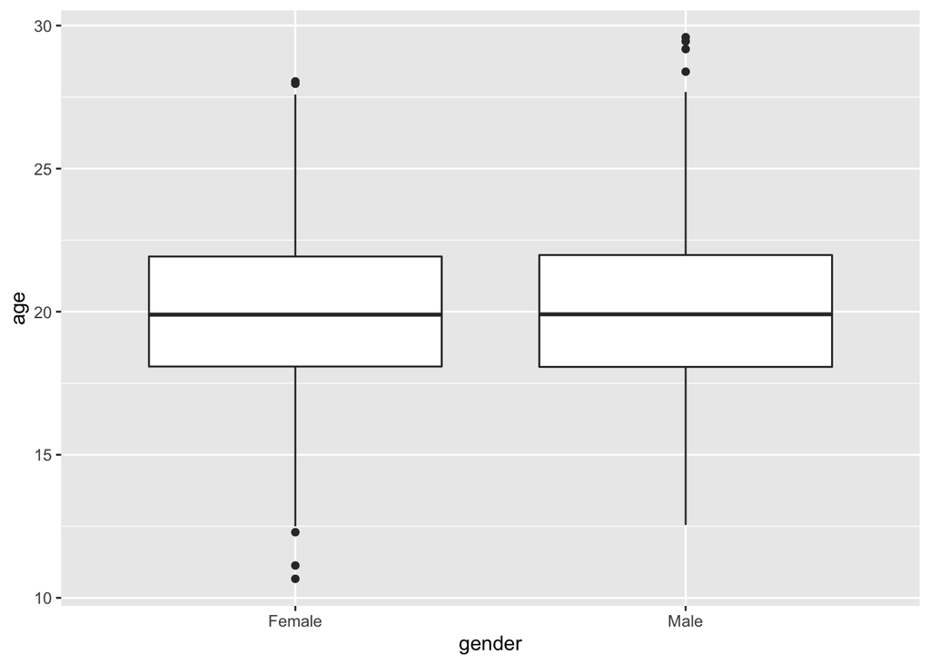

```r
age <- ggplot(data = zombies, aes(x = gender, y = age))
age <- age + geom_boxplot()
age
```

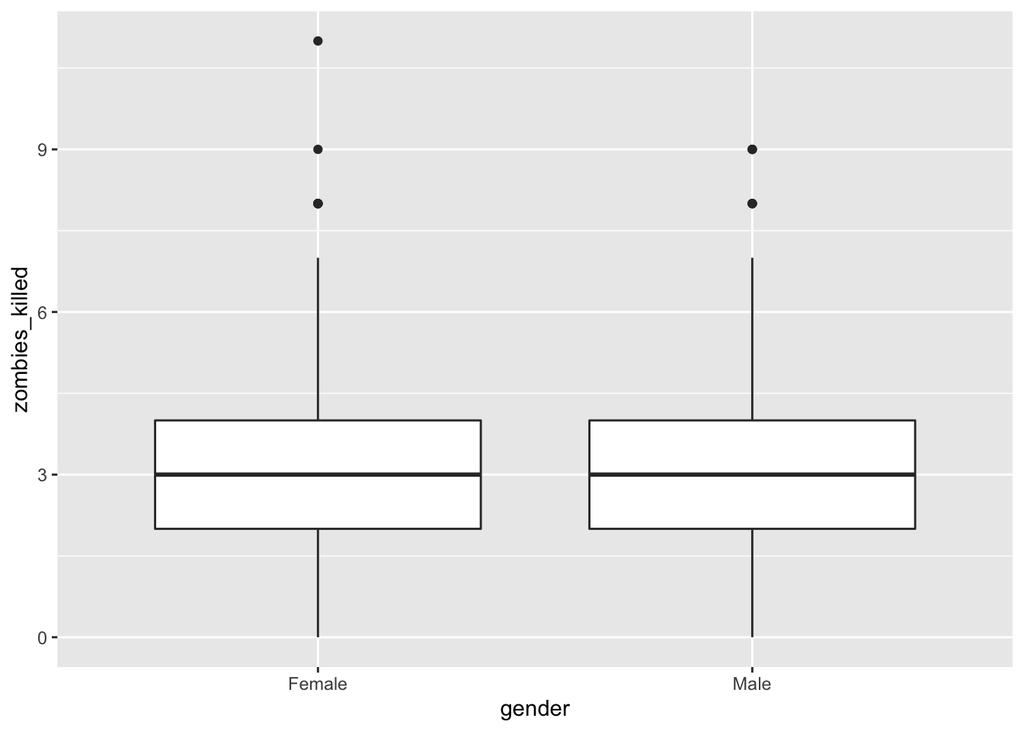

```r
zombies_killed <- ggplot(data = zombies, aes(x = gender, y = zombies_killed))
zombies_killed <- zombies_killed + geom_boxplot()
zombies_killed
```

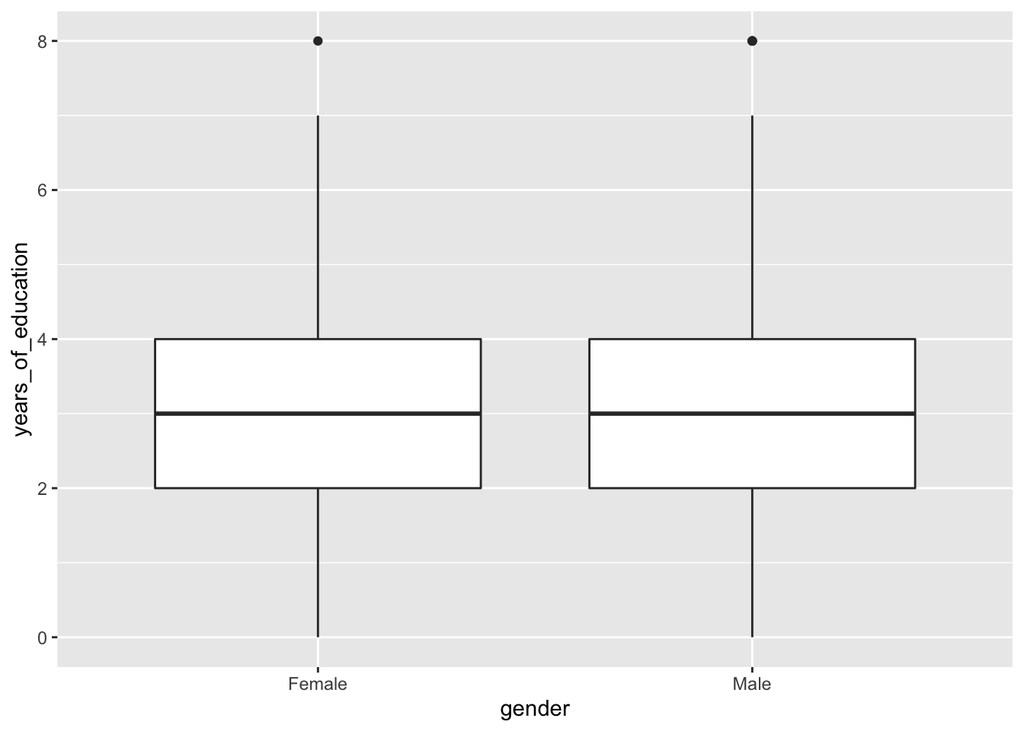

```r
years_of_education <- ggplot(data = zombies, aes(x = gender, y = years_of_education))
years_of_education <- years_of_education + geom_boxplot()
years_of_education
```

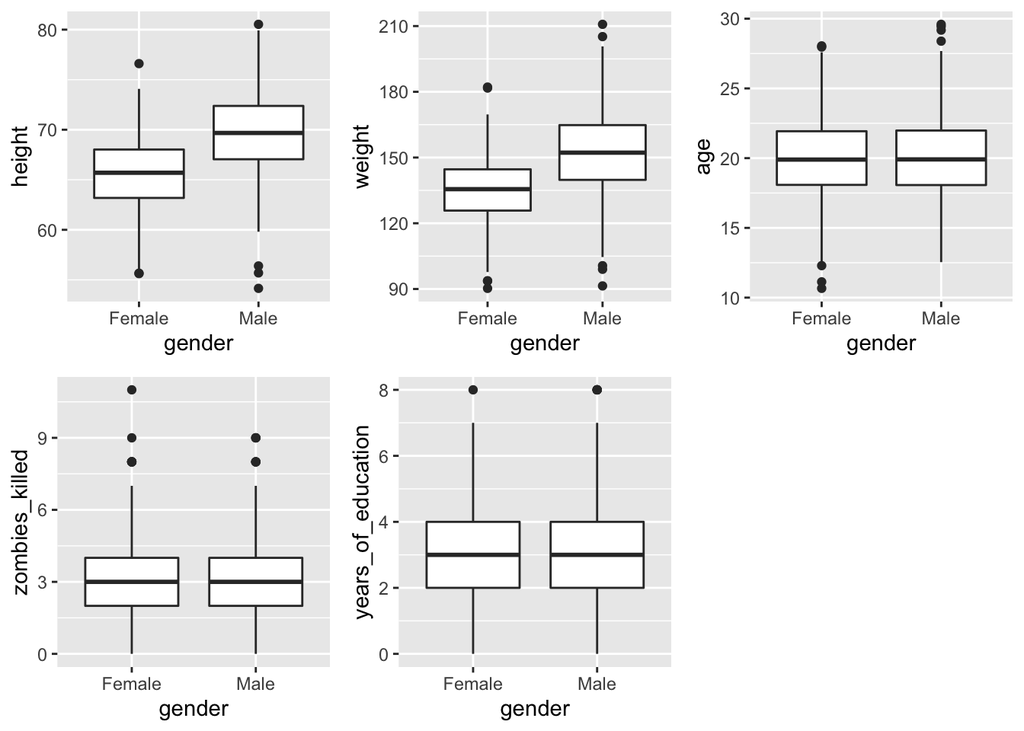

```r
grid.arrange(height, weight, age, zombies_killed, years_of_education, ncol=3)
```

```r
#grid.arrange() function allows you to see all 5 graphs side by side
```

##3. Use {ggplot} to make scatterplots of height and weight in relation to age. Do these variables seem to be related? In what way?

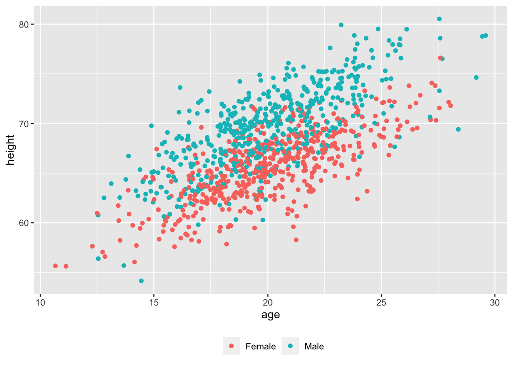

```r
height.age.plot <- ggplot(data = zombies, aes(x = age, y = height, color = factor(gender)))
height.age.plot <- height.age.plot + geom_point()
height.age.plot <- height.age.plot + theme(legend.position = "bottom", legend.title = element_blank())
height.age.plot
```

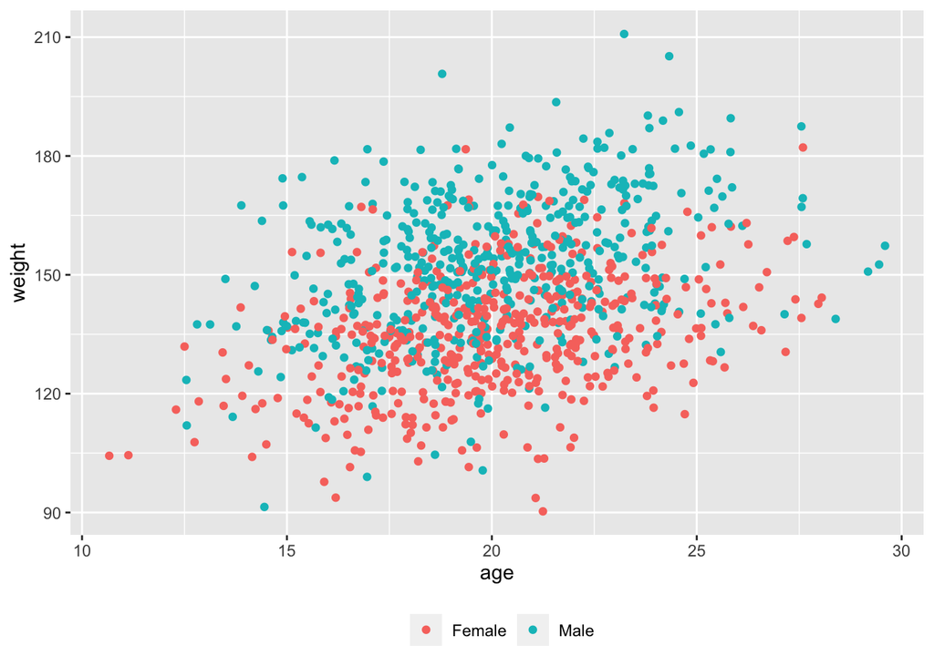

```r
weight.age.plot <- ggplot(data = zombies, aes(x = age, y = weight, color = factor(gender)))
weight.age.plot <- weight.age.plot + geom_point()
weight.age.plot <- weight.age.plot + theme(legend.position = "bottom", legend.title = element_blank())
weight.age.plot
```

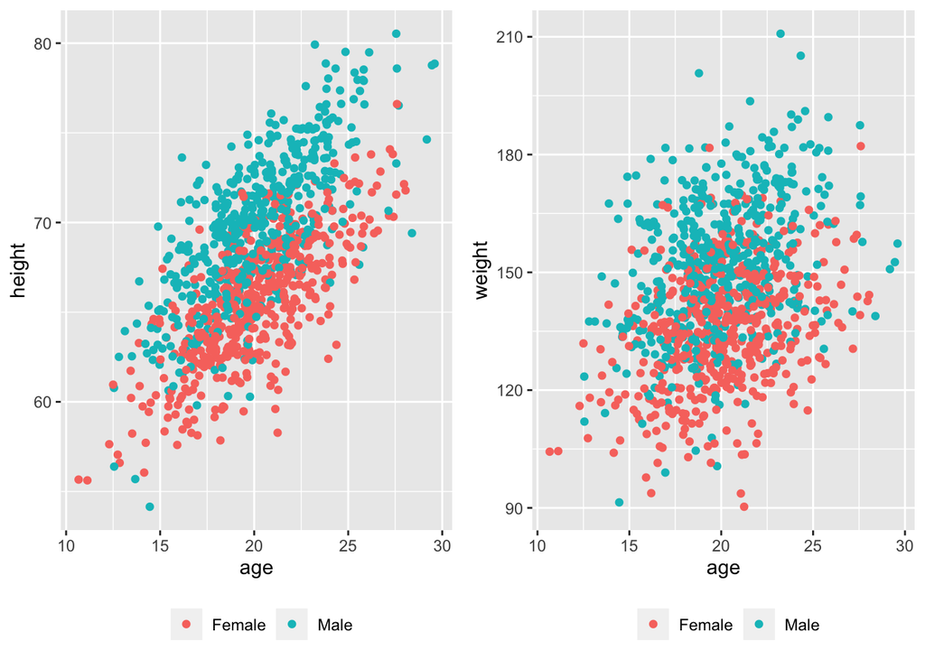

```r
grid.arrange(height.age.plot, weight.age.plot, ncol=2)
```

both the height and the weight plots show a direct, positive relationship between age and height, and age and weight. I found it surprising that there seems to be a stronger relationship between age and height than there is for age and weight… I would expect there to be a stronger relationship between age and height in people’s 20’s because humans don’t usually grow taller after like 18…. or maybe thats just me…

##4. Using histograms and Q-Q plots, check whether the quantitative variables seem to be drawn from a normal distribution. Which seem to be and which do not (hint: not all are drawn from the normal distribution)? For those that are not normal, can you determine from which common distribution they are drawn?

Normally distributed variables

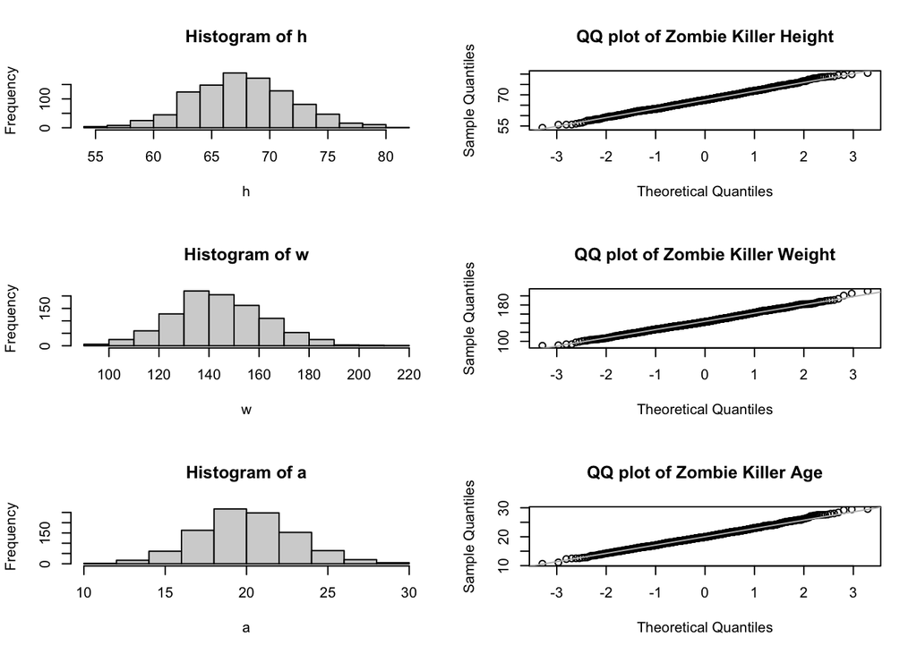

```r
par(mfrow=c(3,2)) #par() function can be used to show all plots at the same time. mfrow=c(3,2) specifies that the graphs will be shown in 3 rows and 2 columns

h <- zombies$height
hist(h)
qqnorm(h, main = "QQ plot of Zombie Killer Height")
qqline(h, col = "gray")

w <- zombies$weight
hist(w)
qqnorm(w, main = "QQ plot of Zombie Killer Weight")
qqline(w, col = "gray")

a <- zombies$age
hist(a)
qqnorm(a, main = "QQ plot of Zombie Killer Age")
qqline(a, col = "gray")
```

Variables that are Not Normally Distributed

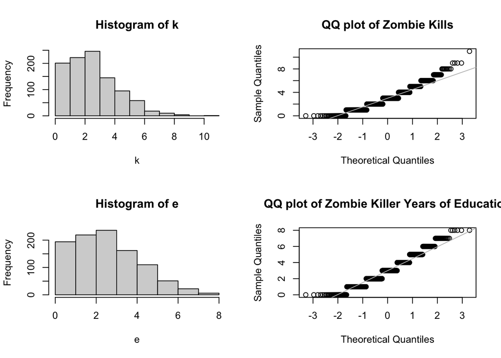

```r
par(mfrow=c(2,2))

k <- zombies$zombies_killed
hist(k)
qqnorm(k, main = "QQ plot of Zombie Kills")
qqline(k, col = "gray")

e <- zombies$years_of_education
hist(e) #histogram is skewed towards lower numbers
qqnorm(e, main = "QQ plot of Zombie Killer Years of Education")
qqline(e, col = "gray") #QQplot looks just like plot zombie kills
```

##For those that are not normal, can you determine from which common distribution they are drawn?

number of zombies killed and years of education are not normal because these data are not random. To determine from which common distribution they are drawn, you can look at the data itself…

```r
zombies$zombies_killed
```

```
##    [1]  2  5  1  5  4  1  0  4  9  2  4  4  2  5  4  2  5  3  2  1  3  1  0  3
##   [25]  8  1  1  1  4  1  1  1  3  2  5  3  8  1  3  8  7  7  7  1  3  2  7  2
##   [49]  2  6  6  2  1  1  3  7  3  5  6  3  4  3  1  1  4  3  1  1  1  3  2  4
##   [73]  3  4  2  3  3  0  4  1  1  2  4  3  3  4  6  2  2  3  5  4  9  3  4  1
##   [97]  2  2  2  5  3  3  0  3  4  4  3  1  5  6  3  5  3  2  6  3  2  2  2  4
##  [121]  1  4  3  1  3  4  5  5  2  3  2  6  3  5  4  1  1  3  2  1  3  4  4  7
##  [145]  5  1  0  3  3  2  1  0  5  3  3  1  2  4  4  4  5  2  2  5  5  3  6  6
##  [169]  2  4  2  4  5  3  3  4  3  2  3  4  2  4  1  2  4  3  2  5  4  1  1  4
##  [193]  5  3  2  6  4  2  0  1  6  3  2  5  2  4  6  4  4  2  1  4  4  7  5  2
##  [217]  0  2  2  4  5  2  3  2  3  3  0  1  0  3  2  2  4  6  4  4  1  3  3  5
##  [241]  2  2  3  3  3  4  3  1  3  3  2  7  1  0  2  5  4  3  7  1  4  1  0  3
##  [265]  5  3  3  3  8  2  3  2  2  3  3  3  3  7  6  2  4  3  1  3  1  6  2  6
##  [289]  4  0  1  3  2  1  3  6  2  6  5  4  3  0  1  3  1  1  4  2  2  4  2  2
##  [313]  5  2  5  3  3  2  0  2  3  3  1  4  2  3  3  4  1  6  4  2  6  2  1  2
##  [337]  3  5  4  9  1  2  1  3  8  5  2  3  3  1  4  2  1  2  2  2  4  2  4  1
```

[output cut: 27 more lines]

```r
zombies$years_of_education
```

```
##    [1] 1 3 1 6 3 4 4 0 3 3 4 3 1 5 5 2 1 5 1 5 1 2 5 3 0 3 2 2 2 1 1 0 2 2 4 2 4
##   [38] 3 3 6 3 4 2 3 1 3 1 1 7 2 2 0 3 0 4 3 4 2 6 1 2 2 3 3 0 1 3 4 2 3 3 2 2 5
##   [75] 2 3 5 2 2 2 1 2 4 6 3 2 4 3 5 3 3 1 4 3 4 3 1 2 1 2 7 3 2 5 3 6 2 0 5 1 2
##  [112] 1 3 3 1 1 3 4 1 2 4 3 3 1 4 5 3 2 3 1 2 6 1 3 1 6 4 2 3 3 2 4 1 2 4 2 1 2
##  [149] 8 5 3 2 1 1 2 2 3 0 2 4 1 1 2 2 2 2 3 4 4 5 5 4 3 2 6 7 1 2 1 4 3 5 4 5 2
##  [186] 1 1 3 0 4 1 0 2 3 5 4 3 4 1 0 0 2 2 3 2 2 3 4 3 1 3 3 0 4 4 3 7 2 4 3 5 1
##  [223] 4 3 4 6 6 1 3 4 5 4 1 2 4 1 3 4 2 3 3 1 1 2 2 0 3 2 4 5 4 4 3 6 4 3 1 2 4
##  [260] 3 1 2 2 3 4 0 3 3 2 2 3 3 3 2 5 4 2 4 1 7 3 3 0 4 5 7 3 4 3 3 2 1 3 5 1 3
##  [297] 2 4 2 5 4 4 1 3 4 1 1 0 4 4 3 3 0 1 4 2 5 5 2 5 2 6 3 3 2 3 3 6 1 3 1 1 2
##  [334] 3 2 1 6 3 7 1 4 8 2 3 1 2 6 3 0 6 4 7 7 2 2 4 3 1 2 3 6 1 6 5 3 3 2 2 3 5
##  [371] 1 1 5 3 5 3 2 4 4 1 3 5 5 1 1 3 4 1 1 4 5 3 2 4 3 1 5 3 2 3 3 6 0 3 1 2 2
##  [408] 3 2 2 0 2 8 2 3 1 3 5 2 5 3 4 0 4 0 3 5 1 2 6 3 5 2 3 3 2 2 4 5 0 2 6 3 3
##  [445] 2 5 3 1 2 3 1 3 3 4 1 3 1 6 5 5 4 3 4 5 3 3 7 4 3 4 2 2 4 6 3 2 1 4 5 4 3
##  [482] 3 1 1 4 3 3 2 7 1 2 2 4 0 2 2 2 1 3 4 4 3 1 3 2 4 6 5 5 2 2 2 2 4 2 2 0 6
##  [519] 5 7 2 3 2 4 3 3 6 0 4 4 2 1 7 2 6 2 5 4 2 2 3 6 4 2 0 3 3 1 5 5 5 5 3 3 5
##  [556] 4 4 0 3 4 2 1 4 2 2 4 1 1 2 1 2 2 0 2 2 1 2 7 2 4 4 5 5 2 5 3 3 1 1 1 4 1
##  [593] 5 3 4 3 0 3 6 1 3 2 2 1 0 6 3 5 2 1 5 4 4 0 1 3 3 7 1 3 2 4 5 3 2 5 4 1 2
##  [630] 2 0 2 2 5 7 3 2 2 6 0 3 2 2 1 2 1 2 7 4 3 3 5 6 2 4 4 2 5 1 5 2 5 2 4 2 4
##  [667] 5 2 2 4 3 5 5 2 4 6 2 5 3 4 4 1 4 6 2 5 1 7 2 1 1 3 3 3 4 2 1 2 4 5 3 3 1
##  [704] 2 6 2 5 5 2 3 5 3 2 1 3 5 0 3 3 6 3 6 3 2 1 2 2 3 3 2 4 3 2 2 5 4 5 2 4 3
##  [741] 0 1 0 5 3 4 1 4 3 4 4 4 3 0 0 2 4 5 4 2 5 4 1 2 2 2 3 1 4 4 1 2 1 4 4 5 3
##  [778] 2 4 1 3 4 0 4 3 2 3 2 4 7 6 4 6 1 3 2 2 4 2 3 3 3 1 4 2 2 7 1 3 4 3 8 3 3
##  [815] 5 3 3 8 0 2 0 2 5 7 2 1 2 3 3 2 3 3 1 5 2 3 3 6 1 4 4 4 2 3 2 4 6 6 5 5 5
##  [852] 2 1 3 3 3 3 4 4 4 3 2 5 1 1 1 1 4 4 3 2 7 2 6 1 3 3 3 2 4 0 4 5 3 3 2 2 4
##  [889] 3 3 6 1 4 1 2 4 3 2 3 2 2 1 5 3 4 4 2 6 3 5 1 2 3 5 3 4 2 2 4 4 6 1 3 3 5
##  [926] 2 0 5 5 0 3 1 4 3 4 4 5 4 5 5 6 3 5 1 1 2 6 1 4 5 5 3 2 2 3 1 4 1 4 0 1 5
##  [963] 3 4 0 3 5 2 3 3 5 3 2 5 3 2 3 6 3 3 3 1 3 0 4 3 5 2 6 0 5 5 6 4 8 2 2 3 3
## [1000] 1
```

these data are independent counts of integer numbers, which would follow the Poisson distribution

##5. Now use the sample() function to sample ONE subset of 30 zombie survivors (without replacement) from this population and calculate the mean and sample standard deviation for each variable.

###height

```r
?sample()
zombies
```

[output not shown]

[output cut: 1987 more lines]

```r
sample_height <- sample(zombies$height, size = 30, replace = FALSE, prob = NULL)
sample_height
```

```
##  [1] 68.08834 67.19587 64.59859 68.11816 72.95424 70.64534 62.07196 62.61210
##  [9] 65.42384 70.09183 63.85283 69.14401 67.12636 64.79030 65.94303 61.22534
## [17] 72.04628 59.60174 65.00593 65.03123 70.13980 78.76891 68.65733 72.49922
## [25] 77.95399 63.99734 72.06090 62.79189 67.96384 71.59179
```

```r
mean(sample_height)
```

```
## [1] 67.73308
```

```r
sd(sample_height)
```

```
## [1] 4.601543
```

##Also estimate the standard error for each variable, and construct the 95% confidence interval for each mean. Note that for the variables that are not drawn from the normal distribution, you may need to base your estimate of the CIs on slightly different code than for the normal…

standard error

```r
se_height <- (sd(sample_height)/sqrt(30))
se_height
```

```
## [1] 0.8401229
```

construct 95% confidence interval for the mean

```r
x <- sample_height
m <- mean(sample_height)

normalCI = function(x, CIlevel = 0.95) {
    upper = m + qnorm(1 - (1 - CIlevel)/2) * sqrt(var(x)/length(x))
    lower = m + qnorm((1 - CIlevel)/2) * sqrt(var(x)/length(x))
    ci <- c(lower, upper)
    return(ci)
}
normalCI(x, 0.95)
```

```
## [1] 66.08647 69.37969
```

###weight

create sample

```r
sample_weight <- sample(zombies$weight, size = 30, replace = FALSE, prob = NULL)
sample_weight
```

```
##  [1] 145.2308 145.2313 165.9423 126.5542 149.0745 145.1768 141.3945 144.5974
##  [9] 129.9344 128.0137 150.3066 133.1287 154.5116 131.5799 165.5044 175.5042
## [17] 135.8098 180.1173 141.2748 131.5336 171.0194 148.8549 129.8401 154.9884
## [25] 129.2723 137.8759 151.4303 150.8109 125.8278 161.2081
```

mean

```r
mean(sample_weight)
```

```
## [1] 146.0516
```

standard deviation

```r
sd(sample_weight)
```

```
## [1] 15.10825
```

standard error

```r
se_weight <- (sd(sample_weight)/sqrt(30))
se_weight
```

```
## [1] 2.758377
```

95% Confidence Interval

```r
x <- sample_weight
m <- mean(sample_weight)
normalCI(x, 0.95)
```

```
## [1] 140.6453 151.4579
```

###age

create sample

```r
sample_age <- sample(zombies$age, size = 30, replace = FALSE, prob = NULL)
sample_age
```

```
##  [1] 23.90511 22.34368 18.15902 20.11017 14.54944 20.29870 22.37782 23.07676
##  [9] 21.35860 22.22479 16.15942 20.92563 18.54973 21.97145 18.61992 17.81768
## [17] 16.60652 17.44240 20.86981 18.02149 24.24839 24.70151 16.33405 26.13428
## [25] 18.85515 20.30216 19.58831 17.42398 24.19646 21.61323
```

mean

```r
mean(sample_age)
```

```
## [1] 20.29286
```

standard deviation

```r
sd(sample_age)
```

```
## [1] 2.900171
```

standard error

```r
se_age <- (sd(sample_age)/sqrt(30))
se_age
```

```
## [1] 0.5294963
```

95% Confidence Interval

```r
x <- sample_age
m <- mean(sample_age)
normalCI(x, 0.95)
```

```
## [1] 19.25506 21.33065
```

###number of zombies killed

create sample

```r
sample_zombies_killed <- sample(zombies$zombies_killed, size = 30, replace = FALSE, prob = NULL)
sample_zombies_killed
```

```
##  [1] 4 1 2 3 6 6 3 2 2 4 3 3 4 5 6 5 2 2 7 6 4 1 0 4 4 4 6 3 4 2
```

mean

```r
mean(sample_zombies_killed)
```

```
## [1] 3.6
```

standard deviation

```r
sd(sample_zombies_killed)
```

```
## [1] 1.753814
```

standard error

```r
se_zombies_killed <- (sd(sample_zombies_killed)/sqrt(30))
se_zombies_killed
```

```
## [1] 0.3202011
```

95% Confidence Interval

Write function to calculate confidence intervals under Poisson Distribution

```r
x <- mean(sample_zombies_killed)


poisson95CI = function(x) {
    upper = x + 1.96*(sqrt(x/30))
    lower = x - 1.96*(sqrt(x/30))
    ci <- c(lower, upper)
    return(ci)
}

poisson95CI(x)
```

```
## [1] 2.921036 4.278964
```

###years of education create sample

```r
sample_years_of_education <- sample(zombies$years_of_education, size = 30, replace = FALSE, prob = NULL)
sample_years_of_education
```

```
##  [1] 4 6 4 4 5 1 2 5 2 2 0 3 4 3 2 1 1 3 1 2 1 5 5 6 1 2 0 2 4 1
```

mean

```r
mean(sample_years_of_education)
```

```
## [1] 2.733333
```

standard deviation

```r
sd(sample_years_of_education)
```

```
## [1] 1.760355
```

standard error

```r
se_years_of_education <- (sd(sample_years_of_education)/sqrt(30))
se_years_of_education
```

```
## [1] 0.3213954
```

95% Confidence Interval

```r
x <- mean(sample_years_of_education)
poisson95CI(x)
```

```
## [1] 2.141715 3.324952
```

##6. Now draw 99 more random samples of 30 zombie apocalypse survivors, and calculate the mean for each variable for each of these samples. Together with the first sample you drew, you now have a set of 100 means for each variable (each based on 30 observations), which constitutes a sampling distribution for each variable.

###height

```r
set <- NULL
n <- zombies$height
for (i in 1:99) {
    set[i] <- mean(sample(n, size = 30, replace = FALSE, prob = NULL))
}
sampling_distribution <- set[]
sampling_distribution
```

```
##  [1] 67.12479 66.86731 68.11539 67.03027 68.06160 67.93819 69.11924 67.72541
##  [9] 68.50880 67.99375 68.40003 67.57232 67.25129 67.83287 67.23453 68.07405
## [17] 67.41664 65.88470 67.17157 67.30179 68.04668 68.14133 68.49976 68.18693
## [25] 67.80493 66.53866 69.56309 67.13693 67.68320 68.43515 66.67074 67.54606
## [33] 66.72710 68.29794 67.63144 68.27367 66.84369 66.48050 68.01187 67.36552
## [41] 66.73759 66.73944 68.47353 68.43311 66.89308 66.81085 66.65905 68.90333
## [49] 67.67555 68.37790 68.14650 67.20212 68.07449 67.56861 67.62392 67.62627
## [57] 67.24307 69.07232 68.10018 69.14104 68.05186 67.98098 67.72838 67.52207
## [65] 66.75809 68.03662 67.80455 67.92922 67.82069 67.76661 66.95281 66.74675
## [73] 68.38499 67.61098 67.00942 68.09367 66.78687 66.69926 66.42008 67.99525
## [81] 68.47650 68.30062 67.56423 67.55607 67.61980 69.93368 69.01420 67.74389
## [89] 67.80957 68.51929 66.20116 67.60632 68.41673 68.09820 68.35577 68.15726
## [97] 67.29945 67.46652 67.80587
```

##What are the means and standard deviations of this distribution of means for each variable? How do the standard deviations of means compare to the standard errors estimated in [5]? What do these sampling distributions look like (a graph might help here)? Are they normally distributed? What about for those variables that you concluded were not originally drawn from a normal distribution?

```r
mean(sampling_distribution)
```

```
## [1] 67.71774
```

```r
sd(sampling_distribution)
```

```
## [1] 0.7388951
```